# HW9A

Sydney Ball

2024-03-27

```r
library(tidyverse)
```

### Question 1:

#### As illustrated in the notes and your book, create a factor that will allow you to sort the vector given according to value from lowest to highest. (Show all work and steps; make sure that your work shows use of the factor function)

```r
y <- c("ten", "eight", "twelve", "two", "six", "four")
ordered_levels <- c("two", "four", "six", "eight", "ten", "twelve")
factor(y, levels = ordered_levels)
```

```
## [1] ten    eight  twelve two    six    four
## Levels: two four six eight ten twelve
```

### Question 2:

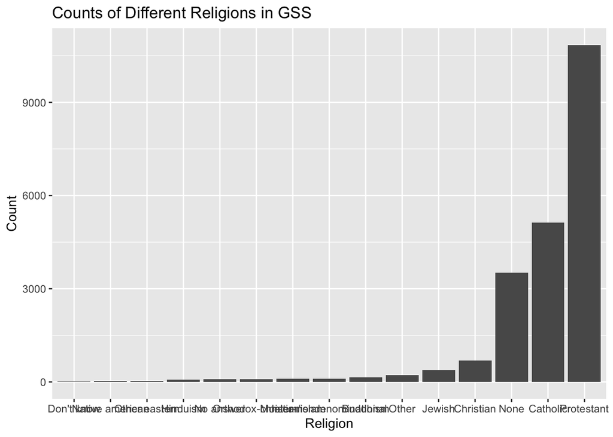

```r
data("gss_cat", package = "forcats")

religion_counts <- gss_cat %>%
  count(relig, sort = TRUE)

religion_counts <- religion_counts %>%
  mutate(relig = fct_reorder(relig, n))

ggplot(religion_counts, aes(x = relig, y = n)) +
  geom_bar(stat = "identity") +
  labs(x = "Religion", y = "Count", title = "Counts of Different Religions in GSS")
```

### Question 3:

#### Use the fct_recode function (along with mutate) to change level ‘Never married’ to ‘Never Married’. You are to perform the change on the marital variable of the gss_cat data frame.

```r
gss_cat2 <- gss_cat %>%
  mutate(marital = fct_recode(marital,
                              "Never Married" = "Never married"))
summary(gss_cat2$marital)
```

```
##     No answer Never Married     Separated      Divorced       Widowed
##            17          5416           743          3383          1807
##       Married
##         10117
```

### Question 4:

```r
gss_cat3 <- gss_cat %>%
  mutate(marital = fct_collapse(marital,
                                "Notmarried" = c("Never married", "Divorced", "Separated", "Widowed"),
                                "Married" = "Married",
                                "No answer" = "No answer"))

marital_counts <- gss_cat3 %>%
  count(marital) %>%
  filter(marital %in% c("No answer", "Not married", "Married"))

print(marital_counts)
```

```
## # A tibble: 2 × 2
##   marital       n
##   <fct>     <int>
## 1 No answer    17
## 2 Married   10117
```

### Question 5:

```r
gss_cat %>%
  group_by(relig) %>%
  summarize(meanage = mean(age, na.rm = TRUE),
            num = n(),
            age = mean(age, na.rm = TRUE)) -> religage

head(religage, 15)
```

```
## # A tibble: 15 × 4
##    relig                   meanage   num   age
##    <fct>                     <dbl> <int> <dbl>
##  1 No answer                  49.5    93  49.5
##  2 Don't know                 35.9    15  35.9
##  3 Inter-nondenominational    40.0   109  40.0
##  4 Native american            38.9    23  38.9
##  5 Christian                  40.1   689  40.1
##  6 Orthodox-christian         50.4    95  50.4
##  7 Moslem/islam               37.6   104  37.6
##  8 Other eastern              45.9    32  45.9
##  9 Hinduism                   37.7    71  37.7
## 10 Buddhism                   44.7   147  44.7
## 11 Other                      41.0   224  41.0
## 12 None                       41.2  3523  41.2
## 13 Jewish                     52.4   388  52.4
## 14 Catholic                   46.9  5124  46.9
## 15 Protestant                 49.9 10846  49.9
```

### Question 6:

#### Use and show R code to produce the scatterplot shown that graphically relates mean age to each religion

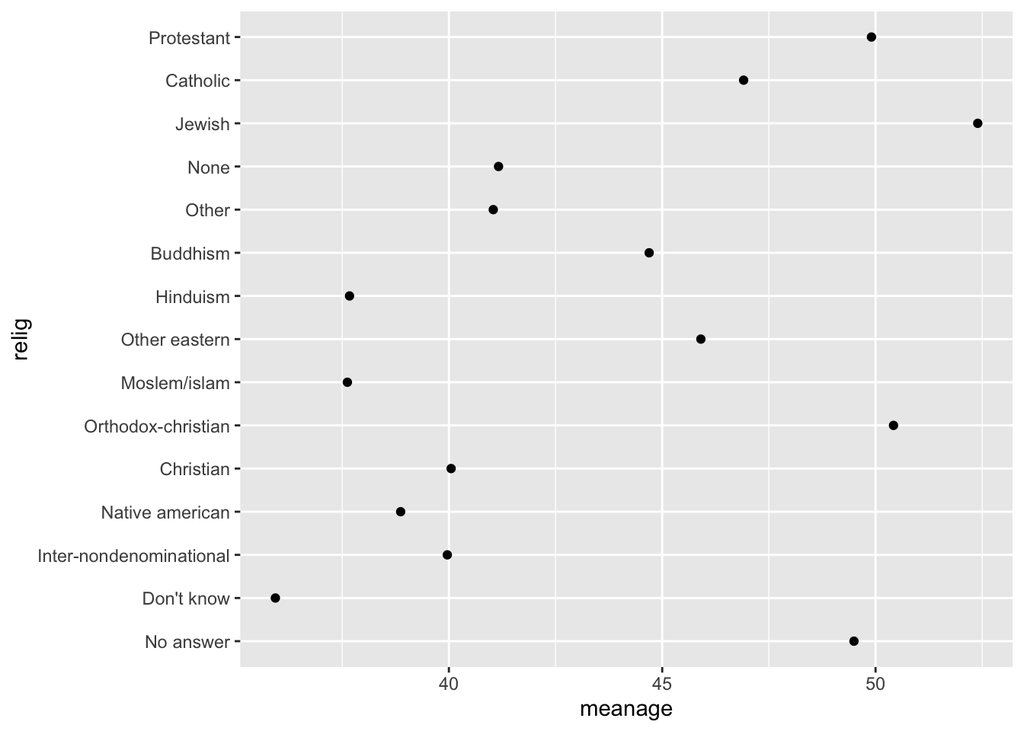

```r
religion_age <- gss_cat %>%
  group_by(relig) %>%
  summarize(meanage = mean(age, na.rm = TRUE))

ggplot(religion_age, aes(x = meanage, y = relig)) +
  geom_point()
```

### Question 7:

#### Now use the fct_reorder function to improve on the scatter plot produced in #6. Your scatter plot should show a progression of lowest to highest mean ages for each religion.

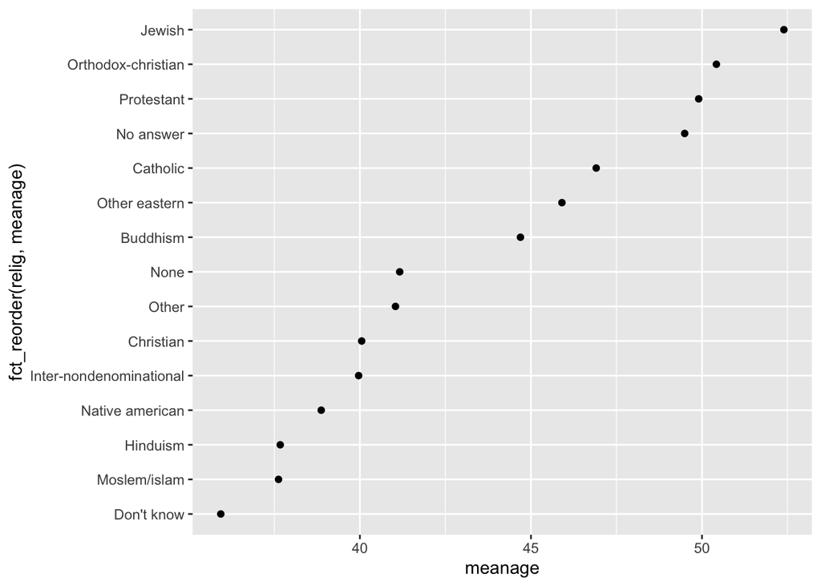

```r
religage <- gss_cat %>%
  group_by(relig) %>%
  summarize(meanage = mean(age, na.rm = TRUE))

ggplot(religage, aes(x = meanage, y = fct_reorder(relig, meanage))) +
  geom_point()
```